# Effect of Various Features on the Trip Duration

## by (Yasser El-Sawaf)

## Investigation Overview

> In this analysis i will investage which features affect the trip duration, i will foucs on gender , user type and days of the week .

## Dataset Overview

> The data contains almost 175k datapoints of bike trips and has these features ['duration_min', 'start_time'end_time', 'start_station_id','end_station_id', 'bike_id', 'user_type', 'member_birth_year','member_gender'], Some data points were removed from the analysis due to inconsistencies or missing information.

## Univariate Exploration

## Distrubtion of Trip Durations

The distribution plotted on log scaale is alomst unimodel and skewed to the right , it shows that the average trip durations peaks around 10 mins (which make sense for bike trips ) , there are few outliers that lies above 200 mins .

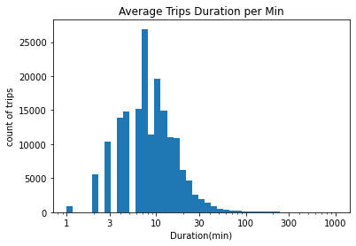

## Distributions of user types and gender

There are a huge gap between the customer and subscriber numbers , and male users are 3 times the number of female useres .

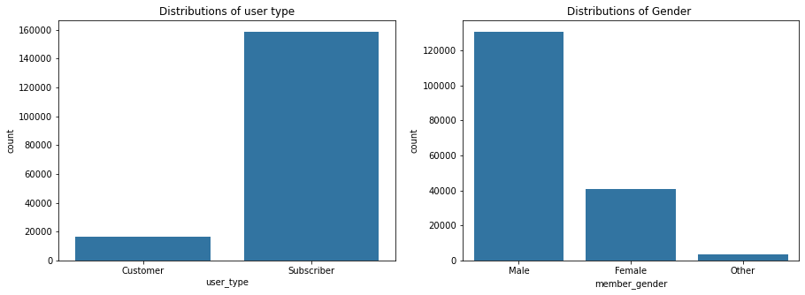

## Ditrbution of member year of birth

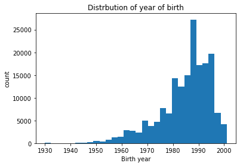

## Distrbution of week days

The number of trips taken on the start of the week (sat ,sun) is almost half the number of trips taken on other days.

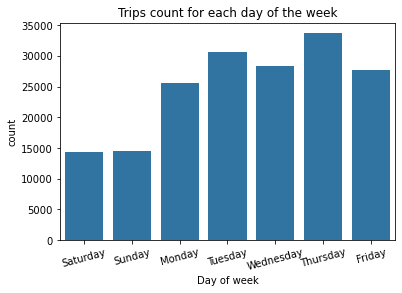

## Bivariate Exploration

## Gender vs User type

The plot didnt show much difference , suggesting that most of the program users tend to subscribe regarding of there gender.

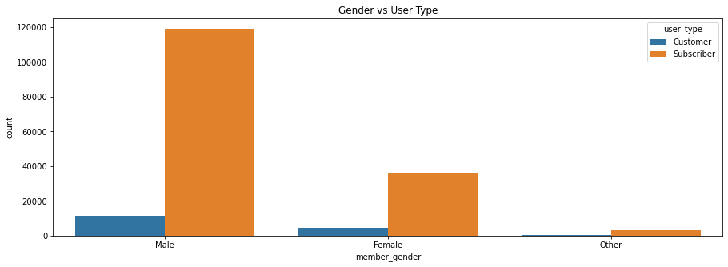

# Trip Durations vs User type and Gender

- Seems that the average trip durations is not affected by gender as all genders seems to have close average(as shown in the right plot )
- The plot on the left for the user type on the other hand shows custmors seems to have a slightly higher average trip duration ( ~ 18 mins) than the subscriber's ( ~ 10 min) .

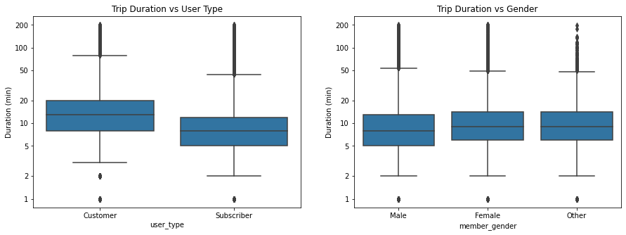

## Distbution of year of birth vs Trip Duration

Seems that the average trip duration ranges for older users are lower than the ranges for younger users , most trips higher than 50 mins is seen from the year range (1965-1995) .

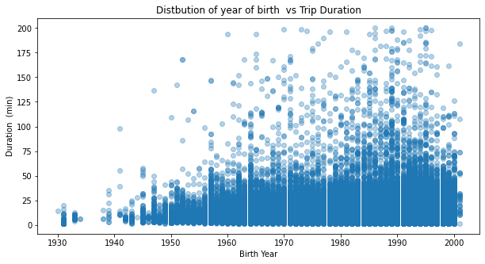

## Average Trip Duration vs Days of the week

Intersting , even though the count of taken on saturday and sundy was much lower than other days almost by half , it seems that the average trip duration on these two days is slightly higher than other days.

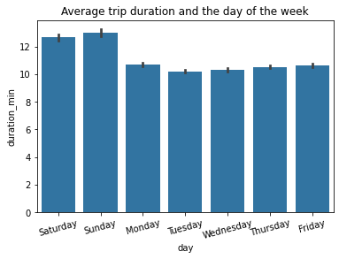

## Multivariate Exploration

Lets dive deepr and see how mutlplie variables will affect the trip duration

## Average trip durations for diff genders and user types

This plot confrims the finding from the bivariate plot which is the customers tend to have higher average trip durations , but interestingly this plot shows that the female customers have the highest average overall (20 mins) , while the male subscribers have the lowest average overall (10 mins).

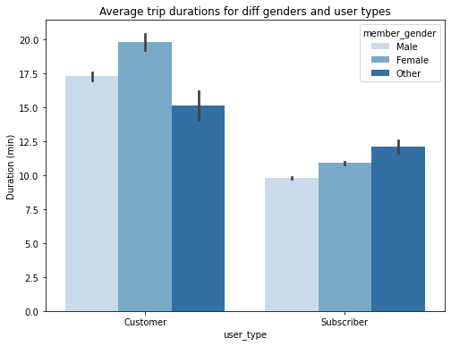

## Average birth year for diff genders and user types

The plot shows almost no difference in age regarding the gender or the user type

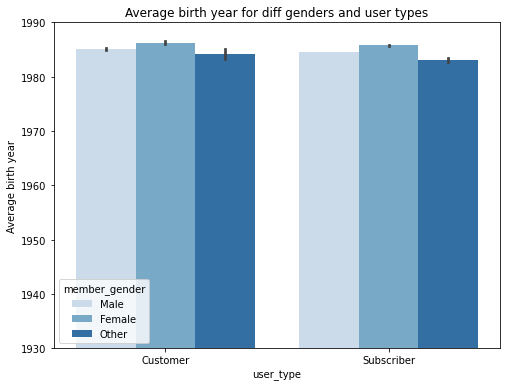

## Average trip durations for each day of the week for diff user types

As the prevoius analysis suggets customer tend to have higher trip duration average overall , but this plot shows that while the average of subscribers is almost the same regardless of the day , customers's average spike on the beginning of the week at sunday.

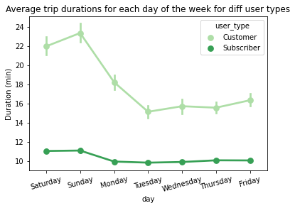